# Evidencia 1 | Analisis Exploratorio de los datos

Daniella Estela Sánchez Hernández A00845754, Andres Rodriguez Cantu A01287002, Isabella Anaís De la Garza Almazán A01663196

2026-06-13

# PARTE I

## 1. Las variables y datos

Los datos que estaremos utilizando se encuentran en los datos crudos en el archivo de datosCalCOFI.csv. A continuación, mostraremos que tipo de datos son, la cabeza decada una de nuestras categorias y un resumen de nuestros datos.

Estructura del dataset de CalCOFI

| Variable | Tipo | Cabeza |
| --- | --- | --- |
| Cst_Cnt | int | 27293 27293 27294 27294 27294 27294 27295 27295 27295 27295 … |
| Depth_zone | chr | “Very shallow” “Shallow” “Very shallow” “Shallow” … |
| mean_ChlorA | num | 0.943 0.198 0.343 0.406 0.15 … |
| mean_NO2uM | num | 0.0833 0.115 0.01 0.042 0.092 … |
| mean_NO3uM | num | 0.733 0.575 0.1 0.3 8.32 … |
| mean_O2ml_L | num | 5.73 5.55 5.74 5.68 4.69 … |
| mean_O2Sat | num | 99.2 96.5 100.5 99.3 78.2 … |
| mean_Phaeop | num | 0.45 0.21 0.13 0.194 0.166 … |
| mean_PO4uM | num | 0.433 0.495 0.377 0.4 0.932 … |
| mean_Salnty | num | 33.1 33.3 33.2 33.2 33.3 … |
| mean_SiO3uM | num | 4.87 3.52 2.8 2.82 8.14 … |
| mean_T_degC | num | 14.8 15 15.4 15.2 12.9 … |
| Bottom_D | int | 64 64 628 628 628 628 830 830 830 830 … |
| Distance | num | -1.97 -1.97 -6.59 -6.59 -6.59 … |
| Lat_Dec | num | 33 33 32.9 32.9 32.9 … |
| Lon_Dec | num | -117 -117 -117 -117 -117 … |
| IntChl | num | 28.1 28.1 31.9 31.9 31.9 31.9 38.3 38.3 38.3 38.3 … |
| Year | int | 1993 1993 1993 1993 1993 1993 1993 1993 1993 1993 … |
| Quarter | int | 1 1 1 1 1 1 1 1 1 1 … |
| Water_density_class | chr | “Light” “Light” “Light” “Light” … |
| Dist_cat | chr | “Oceánica” “Oceánica” “Oceánica” “Oceánica” … |

```
## [1] 28421    21
```

```
##  [1] "Cst_Cnt"             "Depth_zone"          "mean_ChlorA"
##  [4] "mean_NO2uM"          "mean_NO3uM"          "mean_O2ml_L"
##  [7] "mean_O2Sat"          "mean_Phaeop"         "mean_PO4uM"
## [10] "mean_Salnty"         "mean_SiO3uM"         "mean_T_degC"
## [13] "Bottom_D"            "Distance"            "Lat_Dec"
## [16] "Lon_Dec"             "IntChl"              "Year"
## [19] "Quarter"             "Water_density_class" "Dist_cat"
```

Resumen general de los datos por variable

|  | Cst_Cnt | Depth_zone | mean_ChlorA | mean_NO2uM | mean_NO3uM | mean_O2ml_L | mean_O2Sat | mean_Phaeop | mean_PO4uM | mean_Salnty | mean_SiO3uM | mean_T_degC | Bottom_D | Distance | Lat_Dec | Lon_Dec | IntChl | Year | Quarter | Water_density_class | Dist_cat |
| --- | --- | --- | --- | --- | --- | --- | --- | --- | --- | --- | --- | --- | --- | --- | --- | --- | --- | --- | --- | --- | --- |
|  | Min. :27293 | Length:28421 | Min. : 0.0000 | Min. :0.000000 | Min. :-0.03333 | Min. :0.480 | Min. : 7.347 | Min. :-0.2216 | Min. :0.0525 | Min. :24.42 | Min. : 0.00 | Min. : 4.521 | Min. : 14 | Min. :-374.500 | Min. :29.83 | Min. :-125.8 | Min. : 4.30 | Min. :1993 | Min. :1.000 | Length:28421 | Length:28421 |
|  | 1st Qu.:29345 | Class :character | 1st Qu.: 0.0640 | 1st Qu.:0.003333 | 1st Qu.: 0.18333 | 1st Qu.:3.082 | 1st Qu.: 48.360 | 1st Qu.: 0.0560 | 1st Qu.:0.3420 | 1st Qu.:33.30 | 1st Qu.: 2.50 | 1st Qu.: 9.857 | 1st Qu.: 732 | 1st Qu.:-202.780 | 1st Qu.:32.01 | 1st Qu.:-122.4 | 1st Qu.: 27.30 | 1st Qu.:2000 | 1st Qu.:1.000 | Class :character | Class :character |
|  | Median :31331 | Mode :character | Median : 0.1886 | Median :0.020588 | Median : 5.89500 | Median :5.361 | Median : 90.567 | Median : 0.1224 | Median :0.7340 | Median :33.50 | Median : 6.52 | Median :12.755 | Median :1778 | Median :-101.130 | Median :32.92 | Median :-120.9 | Median : 34.40 | Median :2007 | Median :2.000 | Mode :character | Mode :character |
|  | Mean :31385 | NA | Mean : 0.4837 | Mean :0.058357 | Mean :11.42774 | Mean :4.476 | Mean : 76.024 | Mean : 0.1975 | Mean :1.0842 | Mean :33.50 | Mean : 15.85 | Mean :12.638 | Mean :2344 | Mean :-126.290 | Mean :32.85 | Mean :-120.9 | Mean : 51.34 | Mean :2007 | Mean :2.438 | NA | NA |
|  | 3rd Qu.:33454 | NA | 3rd Qu.: 0.4650 | 3rd Qu.:0.081429 | 3rd Qu.:22.80000 | 3rd Qu.:5.765 | 3rd Qu.:101.725 | 3rd Qu.: 0.2420 | 3rd Qu.:1.8200 | 3rd Qu.:33.81 | 3rd Qu.: 24.92 | 3rd Qu.:15.199 | 3rd Qu.:4028 | 3rd Qu.: -34.710 | 3rd Qu.:33.74 | 3rd Qu.:-119.3 | 3rd Qu.: 49.20 | 3rd Qu.:2013 | 3rd Qu.:3.000 | NA | NA |

## 2. Comprensión inicial del fenómeno y definición del objetivo de indagación

### 2.1 Comprensión inicial del fenómeno:

El programa CalCOFI (California Cooperative Oceanic Fisheries Investigations) es un programa de monitoreo oceanográfico creado en 1949 debido al colapso de la pesquería de sardina en la costa de California. En sí, el programa tuvo como objetivo estudiar y analizar las causas ambientales y biológicas que provocaron la disminución drástica de esta especie.

Sin embargo, en la actualidad, CalCOFI no solo estudia poblaciones pesqueras, sino también dinámicas físicas, químicas y biológicas del océano para poder analizar cómo estas variables ambientales afectan la biodiversidad marina, los ecosistemas y la disponibilidad de recursos pesqueros. El programa recopila información relacionada con el oxígeno, la temperatura, la salinidad, los nutrientes, la productividad biológica y la distribución espacial de las condiciones oceanográficas con el fin de comprender los efectos del cambio climático y las actividades humanas en los ecosistemas marinos.

La base de datos que utiliza este programa contiene 28,421 observaciones y 21 variables: variables físicas, químicas, espaciales y temporales. Entre ellas destacan mediciones de temperatura del agua, oxígeno disuelto, salinidad, nutrientes y clorofila, las cuales permiten estudiar patrones oceanográficos y posibles condiciones de estrés ambiental en distintas regiones del océano.

### 2.2 Exploración y clasificación de variables:

Con apoyo del diccionario de variables y del análisis preliminar de la base de datos, se identificaron distintos tipos de variables asociadas a condiciones oceanográficas específicas. Entre estas variables, se delimitaron las siguientes:

#### 2.2.1 Variables Físicas

Estas variables describen propiedades relacionadas con el comportamiento y la estructura del agua del océano, las cuales son importantes debido a que influyen en la circulación oceánica, la estratificación del agua y las condiciones de habitabilidad de los organismos marinos.

mean_T_degC: temperatura promedio del agua

mean_Salnty: salinidad promedio

Bottom_D: profundidad del fondo marino

Water_density_class: clasificación de densidad del agua

Depth_zone: categoría de profundidad

#### 2.2.2 Variables químicas

Estas variables representan la composición y calidad química del agua. En sí, permiten analizar la disponibilidad de nutrientes y posibles condiciones de estrés ambiental o hipoxia que afectan de manera directa a la biodiversidad marina.

mean_O2ml_L: oxígeno disuelto  
mean_O2Sat: saturación de oxígeno  
mean_NO2uM: concentración de nitritos  
mean_NO3uM: concentración de nitratos  
mean_PO4uM: concentración de fosfatos  
mean_SiO3uM: concentración de silicatos

#### 2.2.3 Variables biológicas

Estas variables permiten estudiar la productividad y actividad fitoplanctónica, enfocándose más en la clorofila, la cual es utilizada como indicador de productividad primaria y abundancia de especies de fitoplancton, la cual es la base fundamental de las cadenas alimenticias marinas.

mean_ChlorA: concentración promedio de clorofila  
IntChl: clorofila integrada  
mean_Phaeop: concentración de feopigmentos

#### 2.2.4 Variables espaciales y temporales

Estas variables son necesarias para identificar patrones geográficos y cambios a través del tiempo. Estas permiten comparar zonas oceánicas y analizar variaciones estacionales/temporales en las condiciones ambientales.

Distance: distancia respecto a la costa  
Lat_Dec: latitud  
Lon_Dec: longitud  
Year: año de muestreo  
Quarter: trimestre del año  
Dist_cat: categoría de distancia oceánica

### 2.3 Reflexión sobre biodiversidad y actividad pesquera

Las variables relacionadas con temperatura, oxígeno disuelto y nutrientes se pueden asociar de manera directa con riesgos para la biodiversidad marina. Por ejemplo, una disminución en los niveles de oxígeno puede generar condiciones hipóxicas que terminan afectando la supervivencia de organismos marinos. Asimismo, variaciones extremas de temperatura pueden alterar migraciones, distribución de especies y ciclos reproductivos, generando como consecuencia desequilibrios ecológicos y modificaciones en las cadenas alimenticias. Además, cambios en la concentración de nutrientes pueden provocar alteraciones en la productividad fitoplanctónica, afectando la disponibilidad de alimento para distintas especies y modificando la dinámica natural de los ecosistemas oceánicos.

De igual manera, variables como clorofila, nitratos y temperatura tienen implicaciones significativas para la actividad pesquera, ya que influyen en la productividad biológica del océano y en la disponibilidad de alimento para especies comerciales. Históricamente, cambios ambientales de este tipo estuvieron relacionados con las fluctuaciones y colapsos de poblaciones de sardina que dieron origen al programa CalCOFI, mencionado previamente.

### 2.4 Objetivo de indagación

El objetivo de indagación para esta situación problema es el siguiente: Analizar cómo varían el oxígeno disuelto, la saturación de oxígeno, la temperatura, la salinidad y la concentración de nutrientes en función de la profundidad y la distancia a la costa, con el propósito de identificar patrones ambientales asociados a posibles condiciones de estrés ecológico y cambios en la productividad biológica marina. Esto permitirá comprender cómo las variaciones oceanográficas podrían relacionarse con riesgos ambientales y posibles afectaciones en la biodiversidad marina. Este análisis resulta relevante en un contexto de sustentabilidad, dado que cambios en estas condiciones afectan directamente la disponibilidad de recursos pesqueros y la salud de los ecosistemas marinos.

## 3. Selección y justificación de variables

Las variables que se utilizaran para este analisis seran las siguientes:

Variables

| Variable | Tipo.de.Variable | Justificación |
| --- | --- | --- |
| mean_O2ml_L | Cuantitativa | Saber el promedio de cuánto oxígeno una zona ambiental marina contiene refleja directamente el tipo de ambiente en el que dichas especies viven. |
| mean_O2Sat | Cuantitativa | La saturación del oxígeno nos permite evaluar la cantidad de oxígeno que la fauna tiene a disponibilidad. |
| mean_T_degC | Cuantitativa | La temperatura cambia el comportamiento de la fauna; alterando su metabolismo, horarios cuando estos van a cazar, si van a procrear, etc… |
| mean_Salnty | Cuantitativa | Checar el cambio de salinidad en las aguas nos permite saber sobre el desplazamiento de ciertas especies; apoyando al cambio parcial o total de un ecosistema. |
| mean_ChlorA | Cuantitativa | Conocer la cantidad de clorofila en el ecosistema nos permite saber que tipo de ambientes son más probables de prosperar; siendo los ambientes con las clorofila los que más materia orgánica poseen, ha… |
| Distance | Cuantitativa | Nos permite comparar distintos ambientes en tamaños. Mientras más grande sea la distancia, el ambiente generalmente es más tranquilo, pero más difícil de que la fauna pueda prosperar. |
| Depth_zone | Categórica | Conocer qué tan profunda es la zona nos permite caracterizar a los tipos de especies que residen en dichas zonas; conocer este dato de manera categórica nos permite clasificar mejor el hábitat en dond… |
| Water_denisty_class | Categórica | Similar a la profundidad, conociendo la densidad del agua, podemos saltar a conclusiones acerca de cómo el ecosistema vive. Por ejemplo, que mientras más densa sea el agua, la población de la fauna su… |

Estas variables juegan un papel extremadamente importante para el análisis oceanico. Un cambio significativo en cada una de estas variables nos da información extremadamente valiosa acerca de la salud del ecosistema. Es cierto que estamos omitiendo algunas variables que nos podrían pintar una escena más completa. Sin embargo, las variables que nosotros analizaremos nos cuentan acerca de cambios en el océano. Mientras que el resto de las variables categorizan cada uno de los ambientes, o bien terminan siendo redundantes; innecesarias para nuestro estudio.

Igualmente, para revisar la calidad de los datos, se verificó la presencia de valores faltantes mediante el comando colSums(is.na()), encontrando que ninguna variable seleccionada presenta NAs (Rbloggers, 2024). Sin embargo, el summary() muestra valores mínimos negativos, como anteriormente descrito, siendo físicamente imposibles ya que no existen concentraciones de nutrientes y pigmentos negativos. Por tanto, se detectó un error de procesamiento y medición, siendo necesario el filtrado de datos antes del siguiente análisis.

## 4. Análisis Estadístico de los datos comparativo por región

### 4.1. Obtener los datos de la base de datos

```
## [ADVERTENCIA]: El archivo ya existe
```

### 4.2. Análisis Numérico

#### 4.2.1. Variable numérica por zona de profundidad

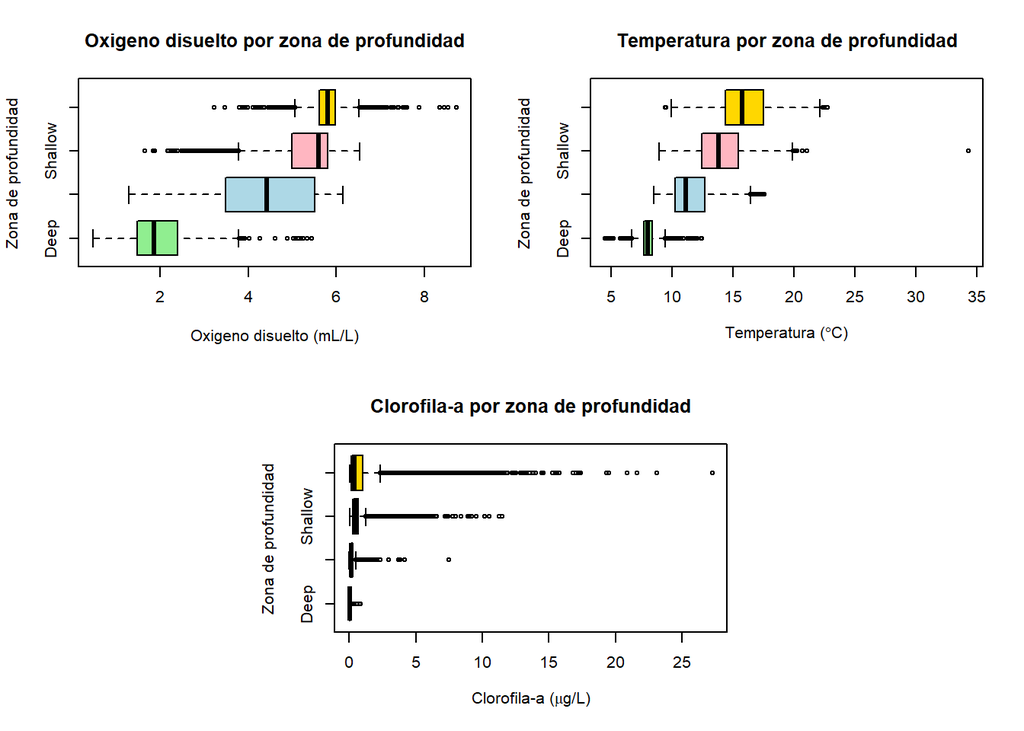

El las figuras de la seccion 4.2.1. Se observan diferencias entre las cuatro categorías. Las zonas very shallow presentan una distribución simétrica, con la mayor concentración de valores entre 14°C y 18°C. Conforme aumenta la profundidad, la distribución se mueve hacia temperaturas menores. La zona Deep tiene la mayoría de sus valores entre 7°C y 10°C, donde podemos ver una disminución progresiva de temperatura con la profundidad debido a la menor cantidad de radiación solar que llega aesas zonas.

#### 4.2.2 Variable numérica por clase de densidad del agua

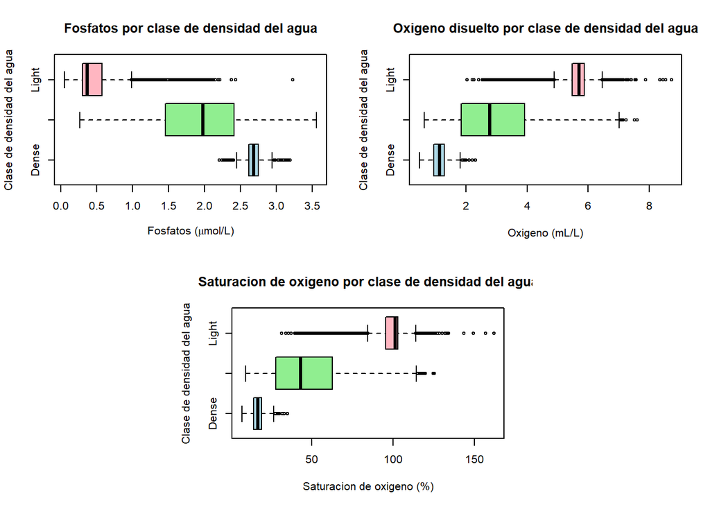

#### 4.2.3 Gráficos comparativos: variable cuantitativa vs cuantitativa

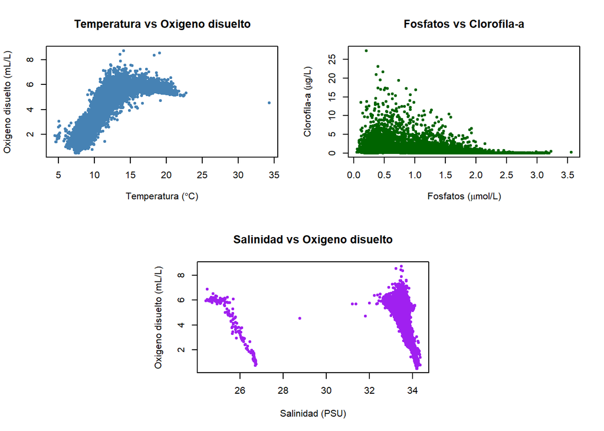

#### 4.2.4 Matriz de correlaciónes

Matriz de correlación de las variables de CalCOFI

|  | mean_O2ml_L | mean_O2Sat | mean_T_degC | mean_Salnty | mean_ChlorA | mean_PO4uM |
| --- | --- | --- | --- | --- | --- | --- |
| mean_O2ml_L | 1.000 | 0.993 | 0.847 | -0.420 | 0.295 | -0.977 |
| mean_O2Sat | 0.993 | 1.000 | 0.901 | -0.408 | 0.274 | -0.989 |
| mean_T_degC | 0.847 | 0.901 | 1.000 | -0.327 | 0.138 | -0.921 |
| mean_Salnty | -0.420 | -0.408 | -0.327 | 1.000 | -0.061 | 0.399 |
| mean_ChlorA | 0.295 | 0.274 | 0.138 | -0.061 | 1.000 | -0.219 |
| mean_PO4uM | -0.977 | -0.989 | -0.921 | 0.399 | -0.219 | 1.000 |

[interactive chart not shown]

En la tabla y figura de la sección 4.2.4. Es fácil de ver que algunas variables contienen más relación que otras. En la tabla, encontramos que la cantidad de mililitros de oxígeno por litro de agua está directamente correlacionado a la saturación de oxígeno. Una correlación que no esperábamos ver fue la correlación negativa entre el fosfato y la cantidad de oxígeno en el mar, uno esperaría que en los océanos se encontraría hasta el fondo acumulados de fosfato. Sin embargo, los datos indican lo contrario. Una última correlación que se nos hizo interesante fue la correlación entre la cantidad de oxígeno y la temperatura del agua. Con estos datos, parecería que no tendría nada que ver, pero tiene todo el sentido del mundo ya que mientras más profundo en el océano te encuentras, el ambiente se hace más frío y hay menos oxígeno. En la tabla, también hay variables que aparentan ser independientes completamente de las variables que habíamos escogido. El ejemplo más claro lo podemos encontrar con la cantidad de clorofila-a que el ambiente posee. Nos sorprendió encontrar esta observación ya que la clorofila-a es parte fundamental de la cadena alimenticia.

### 4.3. Analisis Gráfico

#### 4.3.1. Histogramas Variable cuantitativa

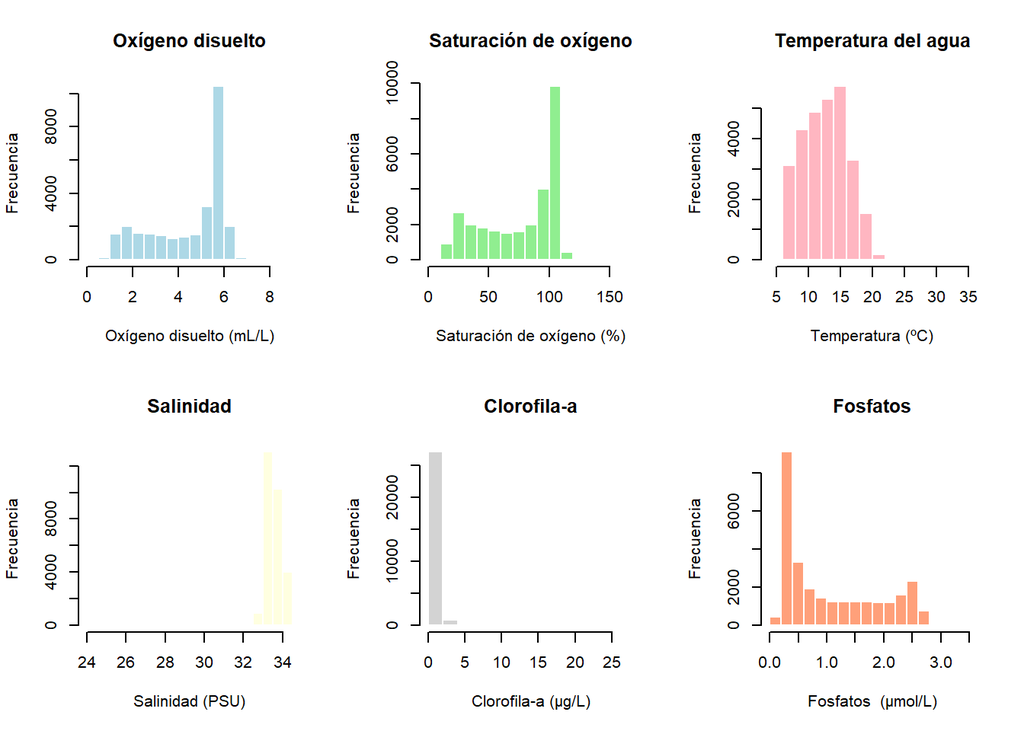

[figure not shown]

#### 4.3.3. Histogramas comparativos Water density class (fosfatos y clorofila)

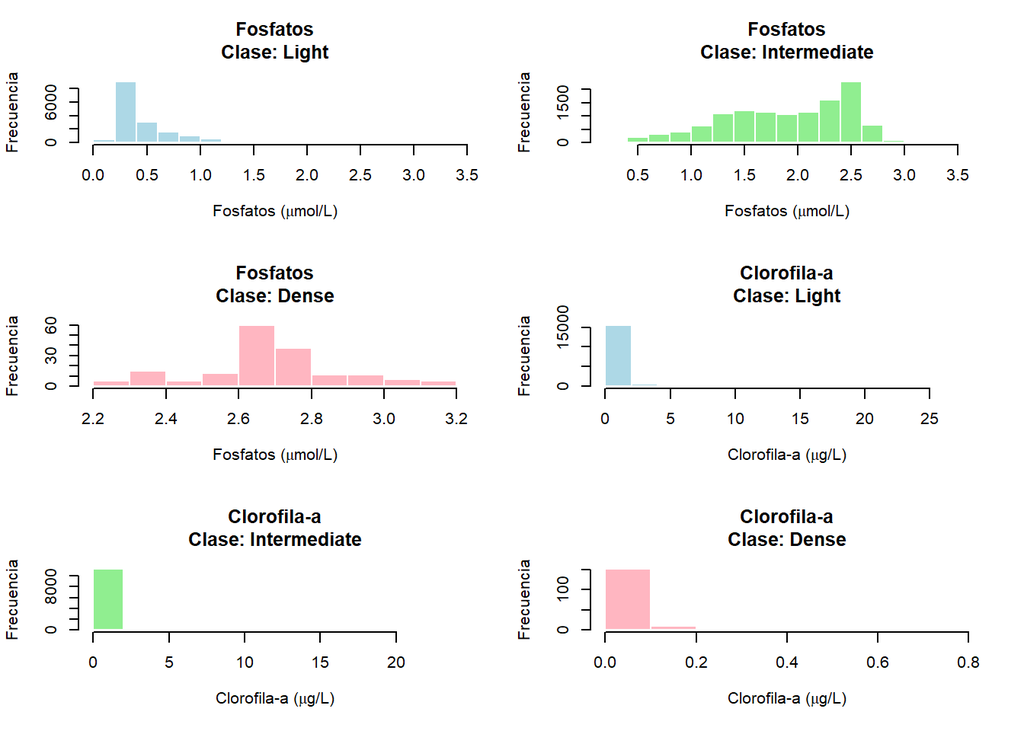

#### 4.3.4. Boxplots (UNIVARIABLES) Variable cuantitativa

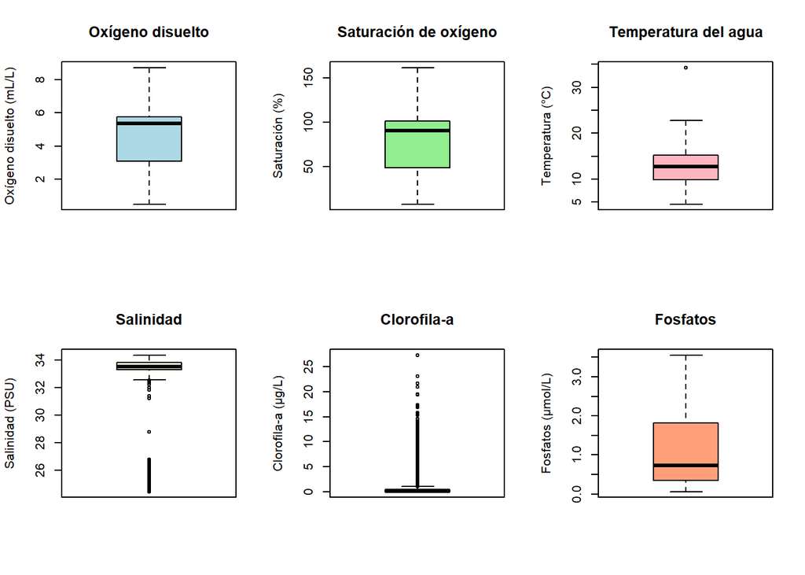

#### 4.3.5. Boxplot (COMPARATIVOS) Depth zone

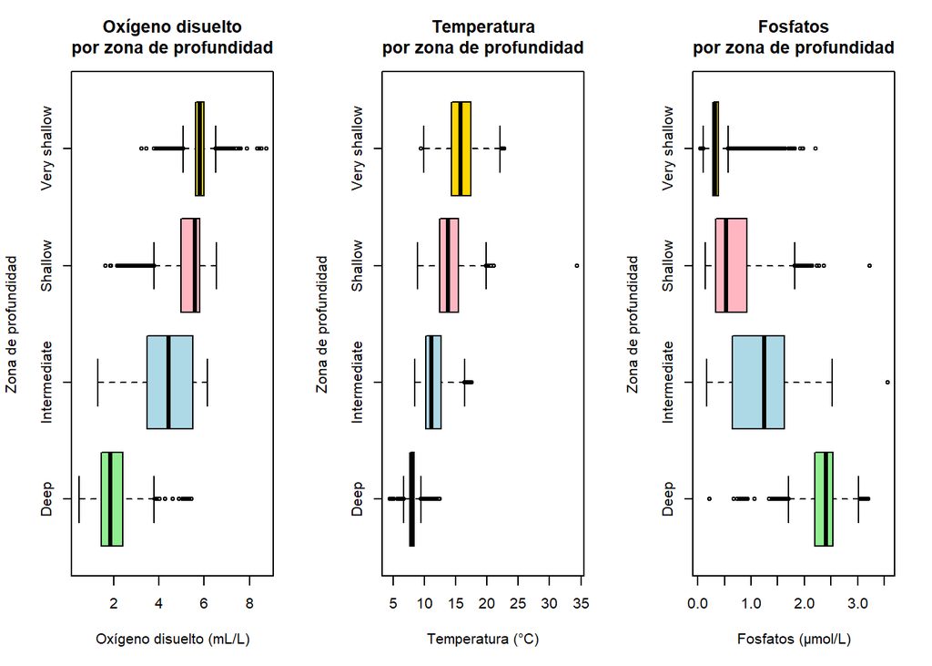

#### 4.3.6. Boxplots (COMPARATIVOS) Water density class

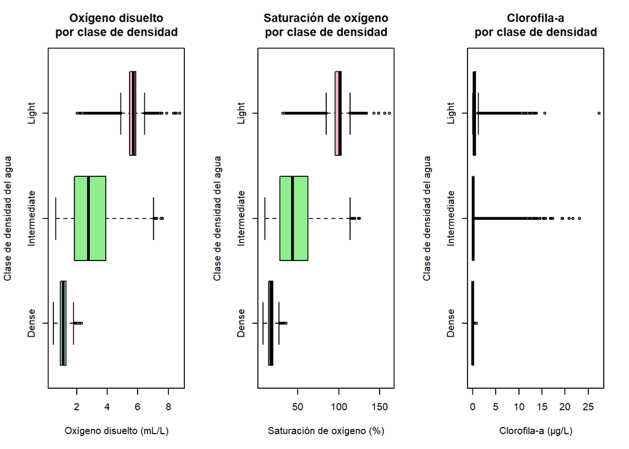

#### 4.3.7. Gráficos de dispersión Cuantitativa vs Cuantitativa

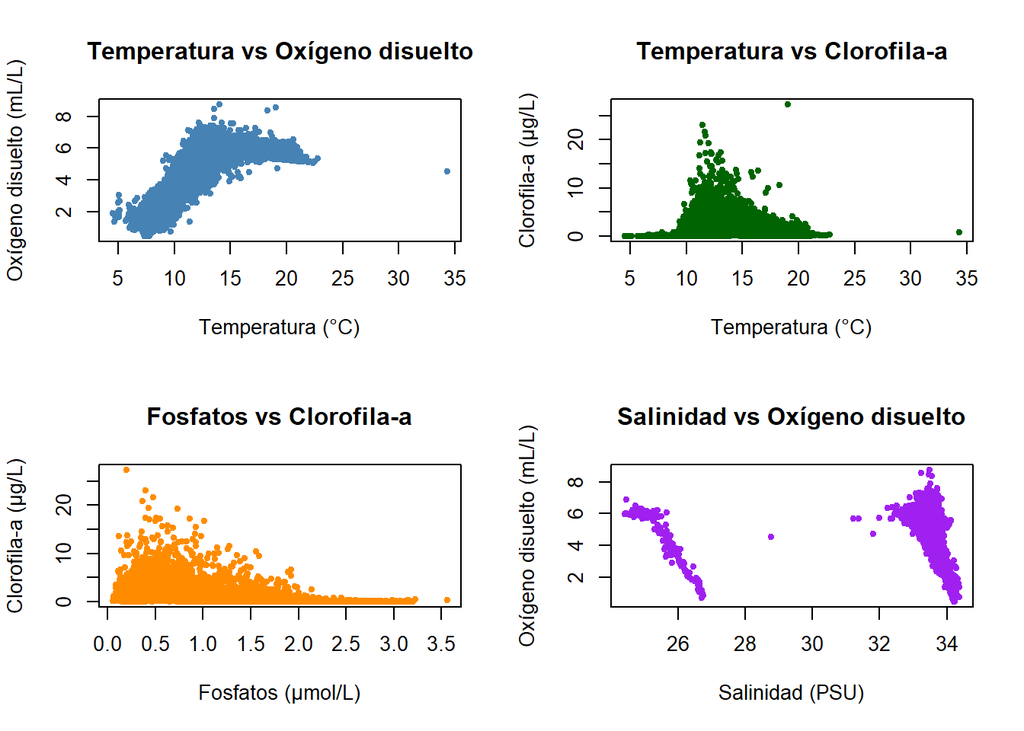

## 5. Interpretación de resultados en el contexto

### 5.2 Uso de medidas

Pongamos de ejemplo las variables que nos hablan directamente sobre la profundidad de la zona 4.3.5. Podemos ver que mientras más profunda es el agua, se encuentra menos oxígeno disuelto; la temperatura decrece y los fosfatos suben. Fundamentando aún más esta idea con la densidad del agua 4.3.6, es fácil de visualizar que mientras más densidad tiene el agua, la propia agua contiene una cantidad y saturación de oxígeno menor a la de si la densidad del agua fuera ligera; además de contener mucha menos clorofila-a que en áreas menos densas.

### 5.3 Interpretación de datos

Con las gráficas, podemos visualizar que dependiendo del ambiente, ciertas zonas experimentan ciertas condiciones ambientales muy variadas; inusualmente variadas. Observando las figuras de 4.3.6, podemos ver que en la cantidad de clorofila-a es muy variable; conteniendo extremos cuando la densidad del agua es baja o intermedia. O bien, en 4.3.5 La cantidad de fosfatos por zona de profundidad varía bastante; hallando valores atípicos en algunas profundidades. Hay muchísimas variables de interés, la temperatura, la salinidad, la cantidad de fosfatos y clorofila-a son valores de extrema importancia. Un pequeño cambio en ellos es capaz de poner a todo el ecosistema en peligro; al no estar adaptados, la fauna termina desplazándose o extinguiéndose en dichas zonas. Evidentemente lo mejor de estos datos es tener más puntos de apoyo en el tiempo; con estos datos tenemos la idea que, cosas como la temperatura y la salinidad del agua están en crecimiento a un ritmo alarmante. Tan solo hace unas cuantas décadas, la temperatura del mar ha crecido más de un grado; el ritmo actual de incremento por década es alrededor de $0.27^{\circ}\text{C}$. Estos tipos de datos y patrones nos hacen entender que estos problemas son problemas que hoy nos están afectando; que si no hacemos algo, la fauna marina decrece y se desplaza; entre otras cosas, perjudicando la pesca, la exploración marítima y exterminando a la biodiversidad marina.

### 5.4 Formulación de preguntas que inicializo la situación problema.

A partir de nuestra interpretación, podemos confirmar el enunciado inicial de la situación problema: *El océano cambia, los datos lo revelan*. Pero estos cambios cómo pueden estar para bien, también pueden estar para mal. Dentro de estos cambios, nosotros queremos dar enfoque en tres preguntas que definirán las siguientes etapas de la situación problema.

Usando estas preguntas, queremos encontrar respuestas acerca del origen de los datos. No necesariamente por una falta de validez, sino para ver cómo estas variables locales afectan a todo el ecosistema global; indagando no sólo en la rigidez de los datos, sino en plantear un origen de la problemática y con ello una posible solución.

## 6. Interpretación y resolución de hipótesis

## 6.1 Planteamiento de preguntas

Ya tenemos nuestra variable y nuestras preguntas definidas. Sin embargo, con estas preguntas realmente no podemos hacer análisis estadistico. Debido a que estas solo se limitan a describir un predicado; hay que reformularlas para que puedan ser analizadas con métodos estadísticos inferenciales.

¿El nivel promedio de oxígeno disuelto en nuestra región cumple con el umbral mínimo óptimo establecido por las normativas ambientales (5 ml/L) necesario para mantener mantener la salud del ecosistema?

¿De qué manera las variaciones e incrementos en la temperatura y la salinidad del agua están alterando significativamente los niveles de oxígeno disuelto (meanO2ml_L), y cómo pone este déficit en riesgo el equilibrio de la biodiversidad marina?

¿Existe una relación significativa entre los niveles de oxígeno disuelto (mean_O2ml_L}) y la biodiversidad marina en nuestra región?

## 6.2 Planteamiento de hipótesis de la primera pregunta

$H_0$: El nivel promedio de oxígeno disuelto en nuestra región es menor o igual al umbral mínimo óptimo establecido por las normativas ambientales (5 ml/L).

$H_1$: El nivel promedio de oxígeno disuelto en nuestra región es mayor al umbral mínimo óptimo establecido por las normativas ambientales (5 ml/L).

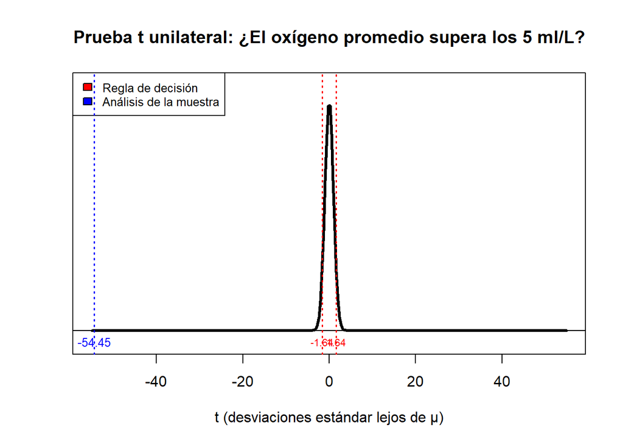

```
## No se rechaza H0: no hay evidencia suficiente para concluir que el promedio supera 5 ml/L
```

## 6.3 Planteamiento de hipótesis de la segunda pregunta

$H_0$: Las variaciones en temperatura y salinidad no alteran significativamente los niveles de oxígeno disuelto ($\beta_{Temp} = 0$ y $\beta_{Sal} = 0$).

$H_1$: Al menos una de las variables (temperatura o salinidad) altera significativamente los niveles de oxígeno disuelto ($\beta_{Temp} \neq 0$ o $\beta_{Sal} \neq 0$).

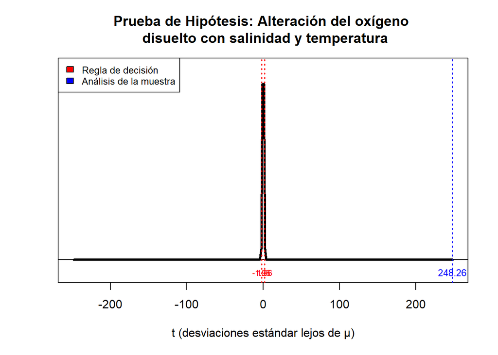

```
## Prueba F global: Se rechaza H0 (p = 0.0000). Al menos una variable afecta significativamente el oxígeno disuelto.
```

```
## Temperatura: Se rechaza H0 (t = 248.26, p = 0.0000). La temperatura afecta significativamente el oxígeno disuelto.
```

```
## Salinidad: Se rechaza H0 (t = -49.86, p = 0.0000). La salinidad afecta significativamente el oxígeno disuelto.
```

## 6.4 Planteamiento de hipótesis de la tercera pregunta

$H_0$: No existe una relación lineal significativa entre el oxígeno disuelto y la clorofila-a ($\rho = 0$).

$H_1$: Si existe una relación lineal significativa entre el oxígeno disuelto y la clorofila-a ($\rho \neq 0$).

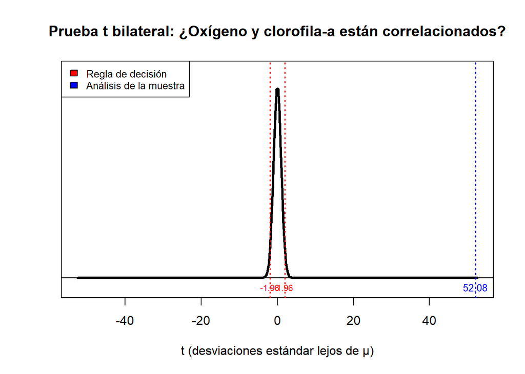

[output not shown]

## 7. Comparación de variables categóricas

### 7.1 Profundidad del agua y el nivel de oxígeno disuelto

```
##
##  Pearson's Chi-squared test
##
## data:  table(datosEq1$Depth_zone, datosEq1$O2_cat)
## X-squared = 15820, df = 3, p-value < 2.2e-16
```

### 7.2 Zona de profundidad y la clase de densidad del agua

```
##
##  Pearson's Chi-squared test
##
## data:  table(datosEq1$Depth_zone, datosEq1$Water_density_class)
## X-squared = 13402, df = 6, p-value < 2.2e-16
```

## 8. Intervalos de confianza

### 8.1 Hipótesis 1: Oxígeno disuelto por zona de profundidad

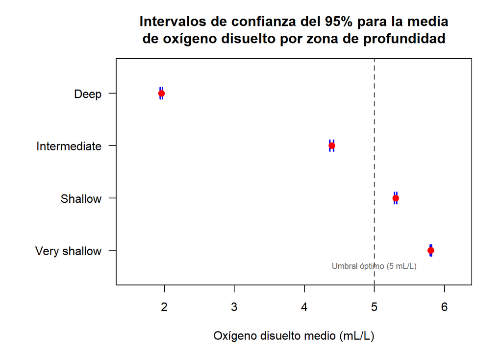

### 8.2 Hipótesis 2: Oxígeno disuelto por clase de densidad del agua

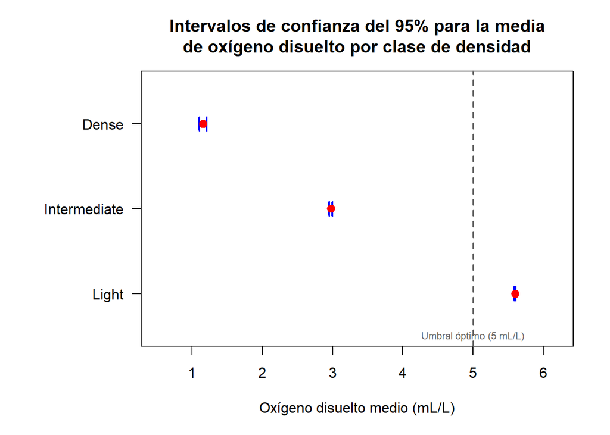

# Referencias

CalCOFI. (2021). *CalCOFI conference*. https://calcofi.org/downloads/CalCOFI_Conference/2021/CalCOFI%20Conference%202021%20Proceedings.pdf/

CalCOFI. (2026). *CalCOFI - california cooperative oceanic fisheries investigations*. https://calcofi.org/

CalCOFI. (n.d.a). *Bottle database*. https://calcofi.org/data/oceanographic-data/bottle-database/

CalCOFI. (n.d.b). *History & survey coverage*. https://calcofi.org/about/history/

CalCOFI. (n.d.c). *Station positions*. https://calcofi.org/sampling-info/station-positions/

Sanderson, S. P., II. (2024). *How to find and count missing values in r: A comprehensive guide with examples*. https://www.r-bloggers.com/2024/12/how-to-find-and-count-missing-values-in-r-a-comprehensive-guide-with-examples/

Tecnológico de Monterrey. (2026). *Diccionario-calcofi*. https://experiencia21.tec.mx/courses/648766/files/276456828?wrap=1